# HW10 - Feature Engineering (FE) & EDA Assignment

- **Zhenyu Wang**
- **UNI: zw2847**
- Section 1: EDA & Data Preparation
- Section 2: H2O Initialize
- Section 3: Modeling - GLM Model
- Section 4: Modeling - AutoML Model
- Section 5: Model Summary & Conclusion

## Section 1: EDA

> Import necessary libraries

```python
import pandas as pd
import matplotlib.pyplot as plt
import seaborn as sns
import numpy as np
```

> Load the dataset

```python
df = pd.read_csv("XYZloan_default_selected_vars.csv")
df.head()
```

|  | Unnamed: 0.1 | Unnamed: 0 | id | loan_default | AP001 | AP002 | AP003 | AP004 | AP005 | AP006 | ... | CD162 | CD164 | CD166 | CD167 | CD169 | CD170 | CD172 | CD173 | MB005 | MB007 |
| --- | --- | --- | --- | --- | --- | --- | --- | --- | --- | --- | --- | --- | --- | --- | --- | --- | --- | --- | --- | --- | --- |
| 0 | 0 | 1 | 1 | 1 | 31 | 2 | 1 | 12 | 2017/7/6 10:21 | ios | ... | 13.0 | 13.0 | 0.0 | 0.0 | 1449.0 | 1449.0 | 2249.0 | 2249.0 | 7.0 | IPHONE7 |
| 1 | 1 | 2 | 2 | 0 | 27 | 1 | 1 | 12 | 2017/4/6 12:51 | h5 | ... | -99.0 | -99.0 | -99.0 | -99.0 | -99.0 | -99.0 | -99.0 | -99.0 | NaN | WEB |
| 2 | 2 | 3 | 3 | 0 | 33 | 1 | 4 | 12 | 2017/7/1 14:11 | h5 | ... | 3.0 | 2.0 | 33.0 | 0.0 | 33.0 | 0.0 | 143.0 | 110.0 | 8.0 | WEB |
| 3 | 3 | 4 | 4 | 0 | 34 | 2 | 4 | 12 | 2017/7/7 10:10 | android | ... | 0.0 | 0.0 | 0.0 | 0.0 | 0.0 | 0.0 | 0.0 | 0.0 | 10.0 | OPPO |
| 4 | 4 | 5 | 5 | 0 | 47 | 2 | 1 | 12 | 2017/7/6 14:37 | h5 | ... | -99.0 | -99.0 | -99.0 | -99.0 | -99.0 | -99.0 | -99.0 | -99.0 | NaN | WEB |

5 rows × 89 columns

> Summary statistics for the dataset

```python
print(df.shape)
```

```
(80000, 89)
```

```python
print(df.describe())
```

```
       Unnamed: 0.1    Unnamed: 0            id  loan_default         AP001  \
count  80000.000000  80000.000000  80000.000000  80000.000000  80000.000000
mean   39999.500000  40000.500000  40000.500000      0.193600     31.706913
std    23094.155105  23094.155105  23094.155105      0.395121      7.075070
min        0.000000      1.000000      1.000000      0.000000     20.000000
25%    19999.750000  20000.750000  20000.750000      0.000000     27.000000
50%    39999.500000  40000.500000  40000.500000      0.000000     30.000000
75%    59999.250000  60000.250000  60000.250000      0.000000     35.000000
max    79999.000000  80000.000000  80000.000000      1.000000     56.000000

              AP002         AP003         AP004        AP007         AP008  \
count  80000.000000  80000.000000  80000.000000  80000.00000  80000.000000
mean       1.321813      2.014925     11.235413      3.30130      3.117200
std        0.467174      1.196806      2.212313      1.33655      1.306335
min        1.000000      1.000000      3.000000      1.00000      1.000000
25%        1.000000      1.000000     12.000000      2.00000      2.000000
50%        1.000000      1.000000     12.000000      3.00000      3.000000
75%        2.000000      3.000000     12.000000      5.00000      4.000000
max        2.000000      6.000000     12.000000      5.00000      5.000000

       ...         CD160         CD162         CD164         CD166  \
count  ...  79619.000000  79619.000000  79619.000000  79619.000000
mean   ...      6.911956     14.271694     11.773358    909.089313
std    ...     28.007499     38.235012     33.270641   1379.553332
min    ...    -99.000000    -99.000000    -99.000000    -99.000000
25%    ...      2.000000      5.000000      4.000000     84.000000
50%    ...      7.000000     12.000000     10.000000    475.000000
75%    ...     14.000000     23.000000     20.000000   1209.000000
max    ...   1061.000000   2792.000000   1579.000000  48585.000000

              CD167         CD169        CD170          CD172         CD173  \
count  79619.000000  79619.000000  79619.00000   79619.000000  79619.000000
mean     810.786219   1732.693314   1539.33443    2513.226491   2229.606137
std     1245.044602   2441.503517   2172.71384    3404.975112   3005.615048
min      -99.000000    -99.000000    -99.00000     -99.000000    -99.000000
25%       34.000000    309.000000    226.00000     539.000000    414.000000
50%      397.000000   1023.000000    870.00000    1553.000000   1324.000000
75%     1080.000000   2287.000000   2030.00000    3296.000000   2936.000000
max    29664.000000  88364.000000  54651.00000  125352.000000  87312.000000

              MB005
count  77207.000000
mean       5.976272
std        3.641814
min        0.000000
25%        3.000000
50%        5.000000
75%        8.000000
max       47.000000

[8 rows x 86 columns]
```

```python
# Check for missing values
print(df.isnull().sum())
```

```
Unnamed: 0.1       0
Unnamed: 0         0
id                 0
loan_default       0
AP001              0
                ...
CD170            381
CD172            381
CD173            381
MB005           2793
MB007              0
Length: 89, dtype: int64
```

> Data Split

```python
from sklearn.model_selection import train_test_split
train, test = train_test_split(
     df, test_size=0.40, random_state=42)
```

```python
train.shape
```

```
(48000, 89)
```

> Distribution of the target variable `loan_default`

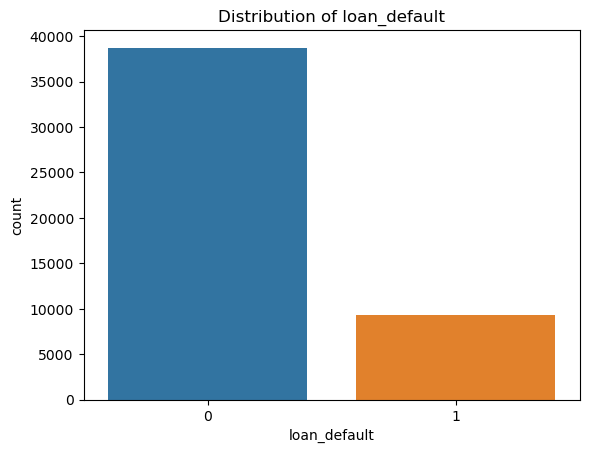

```python
sns.countplot(x='loan_default', data=train)
plt.title('Distribution of loan_default')
plt.show()
```

```python
var = pd.DataFrame(train.dtypes).reset_index()
var.columns = ['varname','dtype']
var['source'] = var['varname'].str[:2]
var.head()
```

|  | varname | dtype | source |
| --- | --- | --- | --- |
| 0 | Unnamed: 0.1 | int64 | Un |
| 1 | Unnamed: 0 | int64 | Un |
| 2 | id | int64 | id |
| 3 | loan_default | int64 | lo |
| 4 | AP001 | int64 | AP |

```python
var['source'].value_counts()
```

```
CD    36
TD    24
AP     9
CR     8
PA     6
Un     2
MB     2
id     1
lo     1
Name: source, dtype: int64
```

```python
# "AP004" is a bad data field and should be removed.
MB_list = list(var[var['source']=='MB']['varname'])
AP_list = list(var[(var['source']=='AP') & (var['varname']!='AP004')]['varname'])
TD_list = list(var[var['source']=='TD']['varname'])
CR_list = list(var[var['source']=='CR']['varname'])
PA_list = list(var[var['source']=='PA']['varname'])
CD_list = list(var[var['source']=='CD']['varname'])
AP_list
```

```
['AP001', 'AP002', 'AP003', 'AP005', 'AP006', 'AP007', 'AP008', 'AP009']
```

```python
train['loan_default'].value_counts(dropna=False)
```

```
0    38736
1     9264
Name: loan_default, dtype: int64
```

## Section 2: H2O Initialize

```python
#pip install h2o
```

```python
import h2o
h2o.init()
```

[output not shown]

| H2O_cluster_uptime: | 03 secs |
| --- | --- |
| H2O_cluster_timezone: | America/New_York |
| H2O_data_parsing_timezone: | UTC |
| H2O_cluster_version: | 3.44.0.2 |
| H2O_cluster_version_age: | 23 days |
| H2O_cluster_name: | H2O_from_python_jimac_ae7ra0 |
| H2O_cluster_total_nodes: | 1 |
| H2O_cluster_free_memory: | 2 Gb |
| H2O_cluster_total_cores: | 8 |
| H2O_cluster_allowed_cores: | 8 |
| H2O_cluster_status: | locked, healthy |
| H2O_connection_url: | http://127.0.0.1:54321 |
| H2O_connection_proxy: | {"http": null, "https": null} |
| H2O_internal_security: | False |
| Python_version: | 3.9.13 final |

```python
from h2o.estimators.glm import H2OGeneralizedLinearEstimator
from h2o.automl import H2OAutoML
```

## Section 3: Modeling - GLM

```python
target='loan_default'
```

> First, we only take 10% of our data to testing our model, if it's work well, we will continue using this model to train for all the data.

```python
train_smpl = train.sample(frac=0.1, random_state=123)
test_smpl = test.sample(frac=0.1, random_state=123)
train_hex = h2o.H2OFrame(train_smpl)
test_hex = h2o.H2OFrame(test_smpl)
```

```
Parse progress: |████████████████████████████████████████████████████████████████| (done) 100%
Parse progress: |████████████████████████████████████████████████████████████████| (done) 100%
```

```python
predictors = CR_list + TD_list + AP_list + MB_list + CR_list + PA_list
```

```python
glm_v1 = H2OGeneralizedLinearEstimator(
        model_id = 'glm_v1',
        seed=1234)
glm_v1.train(predictors,target,training_frame=train_hex)
```

```
glm Model Build progress: |
```

```
██████████████████████████████████████████████████████| (done) 100%
```

```
Model Details
=============
H2OGeneralizedLinearEstimator : Generalized Linear Modeling
Model Key: glm_v1
```

GLM Model: summary

|  | family | link | regularization | number_of_predictors_total | number_of_active_predictors | number_of_iterations | training_frame |
| --- | --- | --- | --- | --- | --- | --- | --- |
|  | gaussian | identity | Elastic Net (alpha = 0.5, lambda = 9.925E-5 ) | 79 | 60 | 1 | Key_Frame__upload_84eb9dd796684f6b2fc3900b5dee476e.hex |

```
ModelMetricsRegressionGLM: glm
** Reported on train data. **

MSE: 0.14343674687179642
RMSE: 0.37873044090988567
MAE: 0.2888858510147118
RMSLE: 0.2658830712065621
Mean Residual Deviance: 0.14343674687179642
R^2: 0.06563236310297471
Null degrees of freedom: 4799
Residual degrees of freedom: 4739
Null deviance: 736.8581250000476
Residual deviance: 688.4963849846229
AIC: 4424.876498086201
```

Scoring History:

|  | timestamp | duration | iterations | negative_log_likelihood | objective | training_rmse | training_deviance | training_mae | training_r2 |
| --- | --- | --- | --- | --- | --- | --- | --- | --- | --- |
|  | 2023-12-02 01:31:30 | 0.000 sec | 0 | 736.8581250 | 0.1535121 |  |  |  |  |
|  | 2023-12-02 01:31:30 | 0.107 sec | 1 |  |  | 0.3787304 | 0.1434367 | 0.2888859 | 0.0656324 |

Variable Importances:

| variable | relative_importance | scaled_importance | percentage |
| --- | --- | --- | --- |
| MB007.DOOV | 0.4132223 | 1.0 | 0.1022373 |
| MB007.MC-X7MINI | 0.3658313 | 0.8853135 | 0.0905121 |
| MB007.BIFER | 0.3436860 | 0.8317219 | 0.0850330 |
| MB007.KOPO | 0.3346042 | 0.8097440 | 0.0827861 |
| MB007.CMCC | 0.2186950 | 0.5292431 | 0.0541084 |
| TD054.60.0 | 0.2063606 | 0.4993938 | 0.0510567 |
| TD054.nan | 0.2063606 | 0.4993938 | 0.0510567 |
| MB007.WEB | 0.1773465 | 0.4291795 | 0.0438782 |
| MB007.MEITU | 0.1534304 | 0.3713024 | 0.0379610 |
| MB007.IPHONE4 | 0.1437965 | 0.3479882 | 0.0355774 |
| --- | --- | --- | --- |
| MB007.NUBIA | 0.0 | 0.0 | 0.0 |
| MB007.Noinfo | 0.0 | 0.0 | 0.0 |
| MB007.ONEPLUS | 0.0 | 0.0 | 0.0 |
| MB007.SAMSUNG | 0.0 | 0.0 | 0.0 |
| MB007.SGMSGMS | 0.0 | 0.0 | 0.0 |
| MB007.SONY | 0.0 | 0.0 | 0.0 |
| MB007.XIAOLAJIAO | 0.0 | 0.0 | 0.0 |
| MB007.YU-FLY | 0.0 | 0.0 | 0.0 |
| AP006.api | 0.0 | 0.0 | 0.0 |
| PA031 | 0.0 | 0.0 | 0.0 |

```
[79 rows x 4 columns]
```

```
[tips]
Use `model.explain()` to inspect the model.
--
Use `h2o.display.toggle_user_tips()` to switch on/off this section.
```

> Create a function to visulize variable importance

```python
def VarImp(model_name):

    from sklearn.metrics import roc_curve,auc
    from sklearn.metrics import average_precision_score
    from sklearn.metrics import precision_recall_curve
    import matplotlib.pyplot as plt

    # plot the variable importance
    plt.rcdefaults()
    variables = model_name._model_json['output']['variable_importances']['variable']
    y_pos = np.arange(len(variables))
    fig, ax = plt.subplots(figsize = (6,len(variables)/2))
    scaled_importance = model_name._model_json['output']['variable_importances']['scaled_importance']
    ax.barh(y_pos,scaled_importance,align='center',color='green')
    ax.set_yticks(y_pos)
    ax.set_yticklabels(variables)
    ax.invert_yaxis()
    ax.set_xlabel('Scaled Importance')
    ax.set_title('Variable Importance')
    plt.show()
```

> Top 10 `variable_importances`

```python
variable_importances = glm_v1._model_json['output']['variable_importances']['variable'][:10]
scaled_importances = glm_v1._model_json['output']['variable_importances']['scaled_importance'][:10]

# Print the top 10 variable importances along with their scaled importances
for i, (importance, scaled_importance) in enumerate(zip(variable_importances, scaled_importances), start=1):
    print(f"Rank {i}: Variable Importance: {importance}, Scaled Importance: {scaled_importance:.3f}")
```

```
Rank 1: Variable Importance: MB007.DOOV, Scaled Importance: 1.000
Rank 2: Variable Importance: MB007.MC-X7MINI, Scaled Importance: 0.885
Rank 3: Variable Importance: MB007.BIFER, Scaled Importance: 0.832
Rank 4: Variable Importance: MB007.KOPO, Scaled Importance: 0.810
Rank 5: Variable Importance: MB007.CMCC, Scaled Importance: 0.529
Rank 6: Variable Importance: TD054.60.0, Scaled Importance: 0.499
Rank 7: Variable Importance: TD054.nan, Scaled Importance: 0.499
Rank 8: Variable Importance: MB007.WEB, Scaled Importance: 0.429
Rank 9: Variable Importance: MB007.MEITU, Scaled Importance: 0.371
Rank 10: Variable Importance: MB007.IPHONE4, Scaled Importance: 0.348
```

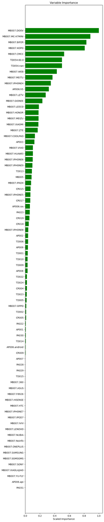

```python
VarImp(glm_v1)
```

```python
predictions = glm_v1.predict(test_hex)
predictions.head()
test_scores = test_hex['loan_default'].cbind(predictions).as_data_frame()
test_scores.head()
```

```
glm prediction progress: |███████████████████████████████████████████████████████| (done) 100%
```

|  | loan_default | predict |
| --- | --- | --- |
| 0 | 0 | 0.263702 |
| 1 | 0 | 0.224656 |
| 2 | 0 | 0.252535 |
| 3 | 0 | 0.404556 |
| 4 | 0 | 0.127447 |

> Define a `createGains` Function, for repetition purpose of generate the gain table

```python
def createGains(model):
    predictions = model.predict(test_hex)
    test_scores = test_hex['loan_default'].cbind(predictions).as_data_frame()

    #sort on prediction (descending), add id, and decile for groups containing 1/10 of datapoints
    test_scores = test_scores.sort_values(by='predict',ascending=False)
    test_scores['row_id'] = range(0,0+len(test_scores))
    test_scores['decile'] = ( test_scores['row_id'] / (len(test_scores)/10) ).astype(int)
    #see count by decile
    test_scores.loc[test_scores['decile'] == 10]=9
    test_scores['decile'].value_counts()

    #create gains table
    gains = test_scores.groupby('decile')['loan_default'].agg(['count','sum'])
    gains.columns = ['count','actual']
    gains

    #add features to gains table
    gains['non_actual'] = gains['count'] - gains['actual']
    gains['cum_count'] = gains['count'].cumsum()
    gains['cum_actual'] = gains['actual'].cumsum()
    gains['cum_non_actual'] = gains['non_actual'].cumsum()
    gains['percent_cum_actual'] = (gains['cum_actual'] / np.max(gains['cum_actual'])).round(2)
    gains['percent_cum_non_actual'] = (gains['cum_non_actual'] / np.max(gains['cum_non_actual'])).round(2)
    gains['if_random'] = np.max(gains['cum_actual']) /10
    gains['if_random'] = gains['if_random'].cumsum()
    gains['lift'] = (gains['cum_actual'] / gains['if_random']).round(2)
    gains['K_S'] = np.abs( gains['percent_cum_actual'] -  gains['percent_cum_non_actual'] ) * 100
    gains['gain']=(gains['cum_actual']/gains['cum_count']*100).round(2)
    gains = pd.DataFrame(gains)
    return(gains)
```

```python
createGains(glm_v1)
```

```
glm prediction progress: |███████████████████████████████████████████████████████| (done) 100%
```

| decile | count | actual | non_actual | cum_count | cum_actual | cum_non_actual | percent_cum_actual | percent_cum_non_actual | if_random | lift | K_S | gain |
| --- | --- | --- | --- | --- | --- | --- | --- | --- | --- | --- | --- | --- |
| 0 | 320 | 117 | 203 | 320 | 117 | 203 | 0.19 | 0.08 | 61.8 | 1.89 | 11.0 | 36.56 |
| 1 | 320 | 71 | 249 | 640 | 188 | 452 | 0.30 | 0.18 | 123.6 | 1.52 | 12.0 | 29.38 |
| 2 | 320 | 93 | 227 | 960 | 281 | 679 | 0.45 | 0.26 | 185.4 | 1.52 | 19.0 | 29.27 |
| 3 | 320 | 65 | 255 | 1280 | 346 | 934 | 0.56 | 0.36 | 247.2 | 1.40 | 20.0 | 27.03 |
| 4 | 320 | 53 | 267 | 1600 | 399 | 1201 | 0.65 | 0.47 | 309.0 | 1.29 | 18.0 | 24.94 |
| 5 | 320 | 58 | 262 | 1920 | 457 | 1463 | 0.74 | 0.57 | 370.8 | 1.23 | 17.0 | 23.80 |
| 6 | 320 | 53 | 267 | 2240 | 510 | 1730 | 0.83 | 0.67 | 432.6 | 1.18 | 16.0 | 22.77 |
| 7 | 320 | 49 | 271 | 2560 | 559 | 2001 | 0.90 | 0.77 | 494.4 | 1.13 | 13.0 | 21.84 |
| 8 | 320 | 28 | 292 | 2880 | 587 | 2293 | 0.95 | 0.89 | 556.2 | 1.06 | 6.0 | 20.38 |
| 9 | 320 | 31 | 289 | 3200 | 618 | 2582 | 1.00 | 1.00 | 618.0 | 1.00 | 0.0 | 19.31 |

> Define the `ROC_AUC` Function to plot the Roc Curve

```python
def ROC_AUC(my_result,df,target):
    from sklearn.metrics import roc_curve,auc
    from sklearn.metrics import average_precision_score
    from sklearn.metrics import precision_recall_curve
    import matplotlib.pyplot as plt

    # ROC
    y_actual = df[target].as_data_frame()
    y_pred = my_result.predict(df).as_data_frame()
    fpr = list()
    tpr = list()
    roc_auc = list()
    fpr,tpr,_ = roc_curve(y_actual,y_pred)
    roc_auc = auc(fpr,tpr)

    # Precision-Recall
    average_precision = average_precision_score(y_actual,y_pred)

    print('')
    print('   * ROC curve: The ROC curve plots the true positive rate vs. the false rositive sate')
    print('')
    print('   * The area under the curve (AUC): A value between 0.5 (random) and 1.0 (perfect), measuring the prediction accuracy')
    print('')
    print('   * Recall (R) = The number of true positives / (the number of true positives + the number of false negatives)')
    print('')

    # plotting
    plt.figure(figsize=(10,4))

    # ROC
    plt.subplot(1,2,1)
    plt.plot(fpr,tpr,color='darkorange',lw=2,label='ROC curve (aare=%0.2f)' % roc_auc)
    plt.plot([0,1],[0,1],color='navy',lw=3,linestyle='--')
    plt.xlim([0.0,1.0])
    plt.ylim([0.0,1.05])
    plt.xlabel('False Positive Rate')
    plt.ylabel('True Positive Rate')
    plt.title('Receiver operating characteristic: AUC={0:0.4f}'.format(roc_auc))
    plt.legend(loc='lower right')

    # Precision-Recall
    plt.subplot(1,2,2)
    precision,recall,_ = precision_recall_curve(y_actual,y_pred)
    plt.step(recall,precision,color='b',alpha=0.2,where='post')
    plt.fill_between(recall,precision,step='post',alpha=0.2,color='b')
    plt.xlabel('Recall')
    plt.ylabel('Precision')
    plt.ylim([0.0,1.05])
    plt.xlim([0.0,1.0])
    plt.title('Precision-Recall curve: PR={0:0.4f}'.format(average_precision))
    plt.show()
```

```
glm prediction progress: |███████████████████████████████████████████████████████| (done) 100%

   * ROC curve: The ROC curve plots the true positive rate vs. the false rositive sate

   * The area under the curve (AUC): A value between 0.5 (random) and 1.0 (perfect), measuring the prediction accuracy

   * Recall (R) = The number of true positives / (the number of true positives + the number of false negatives)
```

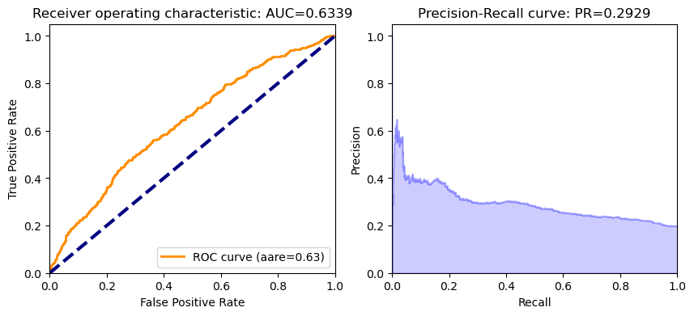

```python
ROC_AUC(glm_v1,test_hex,'loan_default')
```

> - Entire Data

```python
train_hex = h2o.H2OFrame(train)
test_hex = h2o.H2OFrame(test)
```

```
Parse progress: |████████████████████████████████████████████████████████████████| (done) 100%
Parse progress: |████████████████████████████████████████████████████████████████| (done) 100%
```

> - Find the best Hyperparameter using grid search

```python
from h2o.grid.grid_search import H2OGridSearch

# Define hyperparameters for grid search
hyper_params = {
    'alpha': [0.1, 0.3, 0.5],  # Regularization parameter
    'lambda': [1e-6, 1e-9, 1e-12]  # Regularization strength
}

# Create a dictionary of parameters
search_criteria = {'strategy': 'Cartesian'}

# Define the grid search
glm_grid = H2OGridSearch(model=H2OGeneralizedLinearEstimator(model_id='glm_v2', seed=1234),
                          hyper_params=hyper_params,
                          search_criteria=search_criteria)

# Train the grid search
glm_grid.train(x=predictors, y=target, training_frame=train_hex)

# Get the best model from the grid search
glm_v2 = glm_grid.get_grid()[0]
glm_v2
```

```
glm Grid Build progress: |███████████████████████████████████████████████████████| (done) 100%
```

```
Model Details
=============
H2OGeneralizedLinearEstimator : Generalized Linear Modeling
Model Key: Grid_GLM_Key_Frame__upload_a5844693fe71529b3eb26d7dd710441d.hex_model_python_1701498683360_1_model_7
```

GLM Model: summary

|  | family | link | regularization | number_of_predictors_total | number_of_active_predictors | number_of_iterations | training_frame |
| --- | --- | --- | --- | --- | --- | --- | --- |
|  | gaussian | identity | Elastic Net (alpha = 0.1, lambda = 1.0E-12 ) | 141 | 141 | 1 | Key_Frame__upload_a5844693fe71529b3eb26d7dd710441d.hex |

```
ModelMetricsRegressionGLM: glm
** Reported on train data. **

MSE: 0.1472081430701922
RMSE: 0.38367713389019187
MAE: 0.29514344851772367
RMSLE: 0.2693369522687609
Mean Residual Deviance: 0.1472081430701922
R^2: 0.05484945155926946
Null degrees of freedom: 47999
Residual degrees of freedom: 47858
Null deviance: 7476.047999999249
Residual deviance: 7065.990867369226
AIC: 44540.52697418702
```

Scoring History:

|  | timestamp | duration | iterations | negative_log_likelihood | objective | training_rmse | training_deviance | training_mae | training_r2 |
| --- | --- | --- | --- | --- | --- | --- | --- | --- | --- |
|  | 2023-12-02 01:31:40 | 0.000 sec | 0 | 7476.0480000 | 0.1557510 |  |  |  |  |
|  | 2023-12-02 01:31:40 | 0.051 sec | 1 |  |  | 0.3836771 | 0.1472081 | 0.2951434 | 0.0548495 |

Variable Importances:

| variable | relative_importance | scaled_importance | percentage |
| --- | --- | --- | --- |
| MB007.TCL | 0.8958861 | 1.0 | 0.0419051 |
| MB007.ROAM_CAT | 0.8432168 | 0.9412098 | 0.0394415 |
| MB007.BOWAY | 0.8305559 | 0.9270775 | 0.0388492 |
| MB007.BIFER | 0.8032979 | 0.8966518 | 0.0375742 |
| MB007.MC-X7MINI | 0.7980418 | 0.8907849 | 0.0373284 |
| MB007.KOPO | 0.7709179 | 0.8605089 | 0.0360597 |
| MB007.HMI | 0.7601824 | 0.8485258 | 0.0355575 |
| MB007.LINGWIN | 0.7517164 | 0.8390759 | 0.0351615 |
| MB007.ZUOKU | 0.7365680 | 0.8221670 | 0.0344530 |
| MB007.TCT | 0.7066389 | 0.7887598 | 0.0330530 |
| --- | --- | --- | --- |
| MB007.LETV | 0.0022059 | 0.0024622 | 0.0001032 |
| MB007.XIAOLAJIAO | 0.0020932 | 0.0023364 | 0.0000979 |
| TD002 | 0.0020908 | 0.0023337 | 0.0000978 |
| AP006.h5 | 0.0018369 | 0.0020504 | 0.0000859 |
| TD015 | 0.0016649 | 0.0018584 | 0.0000779 |
| CR019 | 0.0011199 | 0.0012500 | 0.0000524 |
| PA031 | 0.0006272 | 0.0007001 | 0.0000293 |
| PA028 | 0.0006168 | 0.0006885 | 0.0000289 |
| MB007.MEIZU | 0.0004287 | 0.0004786 | 0.0000201 |
| PA022 | 0.0003821 | 0.0004265 | 0.0000179 |

```
[141 rows x 4 columns]
```

```
[tips]
Use `model.explain()` to inspect the model.
--
Use `h2o.display.toggle_user_tips()` to switch on/off this section.
```

```python
glm_grid.get_grid()
```

Hyper-Parameter Search Summary: ordered by increasing residual_deviance

|  | alpha | lambda | model_ids | residual_deviance |
| --- | --- | --- | --- | --- |
|  | 0.1 | 1e-12 | Grid_GLM_Key_Frame__upload_a5844693fe71529b3eb26d7dd710441d.hex_model_python_1701498683360_1_model_7 | 7065.9908674 |
|  | 0.3 | 1e-12 | Grid_GLM_Key_Frame__upload_a5844693fe71529b3eb26d7dd710441d.hex_model_python_1701498683360_1_model_8 | 7065.9908674 |
|  | 0.5 | 1e-12 | Grid_GLM_Key_Frame__upload_a5844693fe71529b3eb26d7dd710441d.hex_model_python_1701498683360_1_model_9 | 7065.9908675 |
|  | 0.1 | 1e-09 | Grid_GLM_Key_Frame__upload_a5844693fe71529b3eb26d7dd710441d.hex_model_python_1701498683360_1_model_4 | 7065.9908744 |
|  | 0.3 | 1e-09 | Grid_GLM_Key_Frame__upload_a5844693fe71529b3eb26d7dd710441d.hex_model_python_1701498683360_1_model_5 | 7065.9909878 |
|  | 0.5 | 1e-09 | Grid_GLM_Key_Frame__upload_a5844693fe71529b3eb26d7dd710441d.hex_model_python_1701498683360_1_model_6 | 7065.9912560 |
|  | 0.1 | 1e-06 | Grid_GLM_Key_Frame__upload_a5844693fe71529b3eb26d7dd710441d.hex_model_python_1701498683360_1_model_1 | 7066.0845245 |
|  | 0.3 | 1e-06 | Grid_GLM_Key_Frame__upload_a5844693fe71529b3eb26d7dd710441d.hex_model_python_1701498683360_1_model_2 | 7066.1802023 |
|  | 0.5 | 1e-06 | Grid_GLM_Key_Frame__upload_a5844693fe71529b3eb26d7dd710441d.hex_model_python_1701498683360_1_model_3 | 7066.2718450 |

> ROC AUC Score in Train Data

```
glm prediction progress: |███████████████████████████████████████████████████████| (done) 100%

   * ROC curve: The ROC curve plots the true positive rate vs. the false rositive sate

   * The area under the curve (AUC): A value between 0.5 (random) and 1.0 (perfect), measuring the prediction accuracy

   * Recall (R) = The number of true positives / (the number of true positives + the number of false negatives)
```

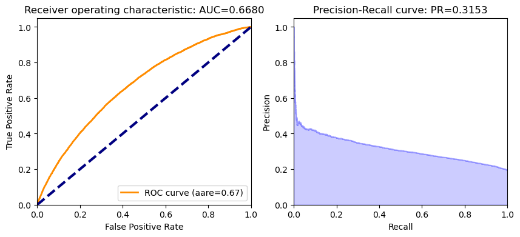

```python
ROC_AUC(glm_v2,train_hex,'loan_default')
```

> ROC AUC Score in Test Data

```
glm prediction progress: |███████████████████████████████████████████████████████| (done) 100%

   * ROC curve: The ROC curve plots the true positive rate vs. the false rositive sate

   * The area under the curve (AUC): A value between 0.5 (random) and 1.0 (perfect), measuring the prediction accuracy

   * Recall (R) = The number of true positives / (the number of true positives + the number of false negatives)
```

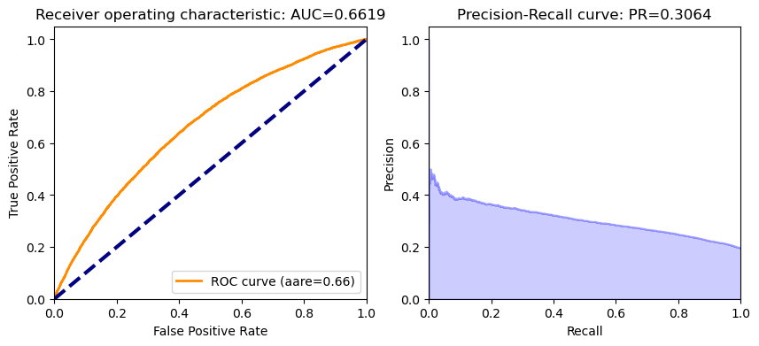

```python
ROC_AUC(glm_v2,test_hex,'loan_default')
```

```python
createGains(glm_v2)
```

```
glm prediction progress: |███████████████████████████████████████████████████████| (done) 100%
```

| decile | count | actual | non_actual | cum_count | cum_actual | cum_non_actual | percent_cum_actual | percent_cum_non_actual | if_random | lift | K_S | gain |
| --- | --- | --- | --- | --- | --- | --- | --- | --- | --- | --- | --- | --- |
| 0 | 3200 | 1167 | 2033 | 3200 | 1167 | 2033 | 0.19 | 0.08 | 622.4 | 1.88 | 11.0 | 36.47 |
| 1 | 3200 | 971 | 2229 | 6400 | 2138 | 4262 | 0.34 | 0.17 | 1244.8 | 1.72 | 17.0 | 33.41 |
| 2 | 3200 | 799 | 2401 | 9600 | 2937 | 6663 | 0.47 | 0.26 | 1867.2 | 1.57 | 21.0 | 30.59 |
| 3 | 3200 | 726 | 2474 | 12800 | 3663 | 9137 | 0.59 | 0.35 | 2489.6 | 1.47 | 24.0 | 28.62 |
| 4 | 3200 | 637 | 2563 | 16000 | 4300 | 11700 | 0.69 | 0.45 | 3112.0 | 1.38 | 24.0 | 26.88 |
| 5 | 3200 | 557 | 2643 | 19200 | 4857 | 14343 | 0.78 | 0.56 | 3734.4 | 1.30 | 22.0 | 25.30 |
| 6 | 3200 | 447 | 2753 | 22400 | 5304 | 17096 | 0.85 | 0.66 | 4356.8 | 1.22 | 19.0 | 23.68 |
| 7 | 3200 | 362 | 2838 | 25600 | 5666 | 19934 | 0.91 | 0.77 | 4979.2 | 1.14 | 14.0 | 22.13 |
| 8 | 3200 | 335 | 2865 | 28800 | 6001 | 22799 | 0.96 | 0.88 | 5601.6 | 1.07 | 8.0 | 20.84 |
| 9 | 3200 | 223 | 2977 | 32000 | 6224 | 25776 | 1.00 | 1.00 | 6224.0 | 1.00 | 0.0 | 19.45 |

> Using Under-Sampling Techniques

```python
y = df[target]
X = df.drop(target,axis=1)
```

```python
y1_cnt = df[target].sum()
y1_cnt
```

```
15488
```

```python
N = 2
y0_cnt = y1_cnt * N
y0_cnt
```

```
30976
```

```python
from imblearn.datasets import make_imbalance
X_rs, y_rs = make_imbalance(X, y,
                            sampling_strategy={1:y1_cnt , 0:  y0_cnt},
                            random_state=123)
X_rs = pd.DataFrame(X_rs)
y_rs = pd.DataFrame(y_rs)
```

```python
y_rs = df[df[target]==1]
X_rs = df[df[target]==0].sample(n=y0_cnt)
smpl = pd.concat([X_rs,y_rs])
train_smpl, test_smpl = train_test_split(
     smpl, test_size=0.40, random_state=42)
```

```python
train_hex = h2o.H2OFrame(train_smpl)
test_hex = h2o.H2OFrame(test_smpl)
```

```
Parse progress: |████████████████████████████████████████████████████████████████| (done) 100%
Parse progress: |████████████████████████████████████████████████████████████████| (done) 100%
```

```python
# Define hyperparameters for grid search
hyper_params = {
    'alpha': [0.1, 0.3, 0.5],  # Regularization parameter
    'lambda': [1e-6, 1e-9, 1e-12]  # Regularization strength
}

# Create a dictionary of parameters
search_criteria = {'strategy': 'Cartesian'}

# Define the grid search
glm_grid = H2OGridSearch(model=H2OGeneralizedLinearEstimator(model_id='glm_v3', seed=1234),
                          hyper_params=hyper_params,
                          search_criteria=search_criteria)

# Train the grid search
glm_grid.train(x=predictors, y=target, training_frame=train_hex)

# Get the best model from the grid search
glm_v3 = glm_grid.get_grid()[0]
glm_v3
```

```
glm Grid Build progress: |███████████████████████████████████████████████████████| (done) 100%
```

```
Model Details
=============
H2OGeneralizedLinearEstimator : Generalized Linear Modeling
Model Key: Grid_GLM_Key_Frame__upload_851dcbb1be892be3485be55007ba4a5e.hex_model_python_1701498683360_2_model_7
```

GLM Model: summary

|  | family | link | regularization | number_of_predictors_total | number_of_active_predictors | number_of_iterations | training_frame |
| --- | --- | --- | --- | --- | --- | --- | --- |
|  | gaussian | identity | Elastic Net (alpha = 0.1, lambda = 1.0E-12 ) | 24348 | 24348 | 50 | Key_Frame__upload_851dcbb1be892be3485be55007ba4a5e.hex |

```
ModelMetricsRegressionGLM: glm
** Reported on train data. **

MSE: 0.1483213214343454
RMSE: 0.3851250724561378
MAE: 0.3224253094526934
RMSLE: NaN
Mean Residual Deviance: 0.1483213214343454
R^2: 0.33270956560598075
Null degrees of freedom: 27877
Residual degrees of freedom: 3529
Null deviance: 6196.554881985784
Residual deviance: 4134.901798946681
AIC: 74612.67901803416
```

Scoring History:

|  | timestamp | duration | iterations | negative_log_likelihood | objective | training_rmse | training_deviance | training_mae | training_r2 |
| --- | --- | --- | --- | --- | --- | --- | --- | --- | --- |
|  | 2023-12-02 01:31:55 | 0.000 sec | 0 | 6196.5548820 | 0.2222740 |  |  |  |  |
|  | 2023-12-02 01:31:55 | 0.069 sec | 1 | 5919.2308217 | 0.2123262 |  |  |  |  |
|  | 2023-12-02 01:31:55 | 0.074 sec | 2 | 5809.9491024 | 0.2084062 |  |  |  |  |
|  | 2023-12-02 01:31:55 | 0.091 sec | 3 | 5770.7394631 | 0.2069998 |  |  |  |  |
|  | 2023-12-02 01:31:55 | 0.105 sec | 4 | 5749.2861368 | 0.2062302 |  |  |  |  |
|  | 2023-12-02 01:31:55 | 0.113 sec | 5 | 5743.7317714 | 0.2060310 |  |  |  |  |
|  | 2023-12-02 01:31:55 | 0.123 sec | 6 | 5741.3206252 | 0.2059445 |  |  |  |  |
|  | 2023-12-02 01:31:55 | 0.133 sec | 7 | 5739.0019861 | 0.2058613 |  |  |  |  |
|  | 2023-12-02 01:31:55 | 0.141 sec | 8 | 5736.2394283 | 0.2057622 |  |  |  |  |
|  | 2023-12-02 01:31:55 | 0.154 sec | 9 | 5732.6433520 | 0.2056332 |  |  |  |  |
| --- | --- | --- | --- | --- | --- | --- | --- | --- | --- |
|  | 2023-12-02 01:31:56 | 0.745 sec | 41 | 4576.7348260 | 0.1641701 |  |  |  |  |
|  | 2023-12-02 01:31:56 | 0.772 sec | 42 | 4537.6247878 | 0.1627672 |  |  |  |  |
|  | 2023-12-02 01:31:56 | 0.781 sec | 43 | 4485.0988858 | 0.1608831 |  |  |  |  |
|  | 2023-12-02 01:31:56 | 0.790 sec | 44 | 4454.9488888 | 0.1598016 |  |  |  |  |
|  | 2023-12-02 01:31:56 | 0.799 sec | 45 | 4384.3271517 | 0.1572684 |  |  |  |  |
|  | 2023-12-02 01:31:56 | 0.807 sec | 46 | 4350.9616802 | 0.1560715 |  |  |  |  |
|  | 2023-12-02 01:31:56 | 0.816 sec | 47 | 4295.9199436 | 0.1540971 |  |  |  |  |
|  | 2023-12-02 01:31:56 | 0.827 sec | 48 | 4267.8870728 | 0.1530916 |  |  |  |  |
|  | 2023-12-02 01:31:56 | 0.838 sec | 49 | 4247.9428793 | 0.1523762 |  |  |  |  |
|  | 2023-12-02 01:31:56 | 0.851 sec | 50 | 4134.9017989 | 0.1483213 | 0.3851251 | 0.1483213 | 0.3224253 | 0.3327096 |

```
[51 rows x 10 columns]
```

Variable Importances:

| variable | relative_importance | scaled_importance | percentage |
| --- | --- | --- | --- |
| MB007.GIONEE | 1.7954712 | 1.0 | 0.0006515 |
| MB007.MEITU | 1.3303180 | 0.7409297 | 0.0004827 |
| MB007.IPHONE5 | 1.0851398 | 0.6043760 | 0.0003938 |
| MB007.ONEPLUS | 0.7306564 | 0.4069441 | 0.0002651 |
| MB007.LENOVO | 0.7270538 | 0.4049376 | 0.0002638 |
| MB007.360 | 0.6651948 | 0.3704848 | 0.0002414 |
| AP005.2017/6/26 16:46 | 0.5428512 | 0.3023447 | 0.0001970 |
| MB007.COOLPAD | 0.5407919 | 0.3011978 | 0.0001962 |
| AP005.2017/4/27 13:34 | 0.5118679 | 0.2850884 | 0.0001857 |
| AP005.2017/5/5 10:52 | 0.4928699 | 0.2745073 | 0.0001789 |
| --- | --- | --- | --- |
| AP005.2017/6/24 8:01 | 0.0006718 | 0.0003741 | 0.0000002 |
| AP005.2017/5/2 15:16 | 0.0005395 | 0.0003005 | 0.0000002 |
| AP005.2017/7/10 4:08 | 0.0005374 | 0.0002993 | 0.0000002 |
| AP005.2017/7/8 18:33 | 0.0004715 | 0.0002626 | 0.0000002 |
| AP005.2017/6/13 16:21 | 0.0004113 | 0.0002291 | 0.0000001 |
| AP005.2017/6/19 13:54 | 0.0003824 | 0.0002130 | 0.0000001 |
| AP005.2017/7/7 20:18 | 0.0002353 | 0.0001310 | 0.0000001 |
| AP005.2017/5/21 8:46 | 0.0002110 | 0.0001175 | 0.0000001 |
| AP005.2017/5/2 21:04 | 0.0001292 | 0.0000720 | 0.0000000 |
| AP005.2017/6/29 12:42 | 0.0000100 | 0.0000056 | 0.0000000 |

```
[24348 rows x 4 columns]
```

```
[tips]
Use `model.explain()` to inspect the model.
--
Use `h2o.display.toggle_user_tips()` to switch on/off this section.
```

> ROC AUC Score in Train Data

```
glm prediction progress: |███████████████████████████████████████████████████████| (done) 100%

   * ROC curve: The ROC curve plots the true positive rate vs. the false rositive sate

   * The area under the curve (AUC): A value between 0.5 (random) and 1.0 (perfect), measuring the prediction accuracy

   * Recall (R) = The number of true positives / (the number of true positives + the number of false negatives)
```

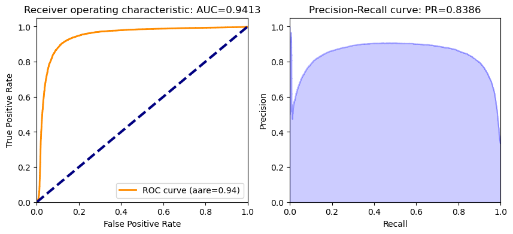

```python
ROC_AUC(glm_v3,train_hex,'loan_default')
```

> ROC AUC Score in Test Data

```
glm prediction progress: |███████████████████████████████████████████████████████| (done) 100%

   * ROC curve: The ROC curve plots the true positive rate vs. the false rositive sate

   * The area under the curve (AUC): A value between 0.5 (random) and 1.0 (perfect), measuring the prediction accuracy

   * Recall (R) = The number of true positives / (the number of true positives + the number of false negatives)
```

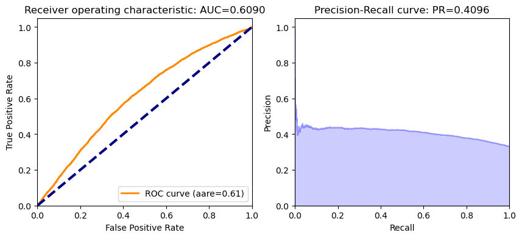

```python
ROC_AUC(glm_v3,test_hex,'loan_default')
```

```python
createGains(glm_v3)
```

```
glm prediction progress: |███████████████████████████████████████████████████████| (done) 100%
```

| decile | count | actual | non_actual | cum_count | cum_actual | cum_non_actual | percent_cum_actual | percent_cum_non_actual | if_random | lift | K_S | gain |
| --- | --- | --- | --- | --- | --- | --- | --- | --- | --- | --- | --- | --- |
| 0 | 1859 | 803 | 1056 | 1859 | 803 | 1056 | 0.13 | 0.09 | 619.1 | 1.30 | 4.0 | 43.20 |
| 1 | 1859 | 799 | 1060 | 3718 | 1602 | 2116 | 0.26 | 0.17 | 1238.2 | 1.29 | 9.0 | 43.09 |
| 2 | 1858 | 790 | 1068 | 5576 | 2392 | 3184 | 0.39 | 0.26 | 1857.3 | 1.29 | 13.0 | 42.90 |
| 3 | 1859 | 751 | 1108 | 7435 | 3143 | 4292 | 0.51 | 0.35 | 2476.4 | 1.27 | 16.0 | 42.27 |
| 4 | 1858 | 660 | 1198 | 9293 | 3803 | 5490 | 0.61 | 0.44 | 3095.5 | 1.23 | 17.0 | 40.92 |
| 5 | 1859 | 595 | 1264 | 11152 | 4398 | 6754 | 0.71 | 0.54 | 3714.6 | 1.18 | 17.0 | 39.44 |
| 6 | 1859 | 539 | 1320 | 13011 | 4937 | 8074 | 0.80 | 0.65 | 4333.7 | 1.14 | 15.0 | 37.94 |
| 7 | 1858 | 489 | 1369 | 14869 | 5426 | 9443 | 0.88 | 0.76 | 4952.8 | 1.10 | 12.0 | 36.49 |
| 8 | 1859 | 400 | 1459 | 16728 | 5826 | 10902 | 0.94 | 0.88 | 5571.9 | 1.05 | 6.0 | 34.83 |
| 9 | 1858 | 365 | 1493 | 18586 | 6191 | 12395 | 1.00 | 1.00 | 6191.0 | 1.00 | 0.0 | 33.31 |

## Section 4: Modeling - AutoML

```python
target='loan_default'
predictors = CR_list + TD_list + AP_list + MB_list + CR_list + PA_list
```

> First, we only take 10% of our data to testing our model, if it's work well, we will continue using this model to train for all the data.

```python
train_smpl = train.sample(frac=0.1, random_state=123)
test_smpl = test.sample(frac=0.1, random_state=123)
train_hex = h2o.H2OFrame(train_smpl)
test_hex = h2o.H2OFrame(test_smpl)
```

```
Parse progress: |████████████████████████████████████████████████████████████████| (done) 100%
Parse progress: |████████████████████████████████████████████████████████████████| (done) 100%
```

```python
# Run AutoML for 20 base models (limited to 1 hour max runtime by default)
aml_v1 = H2OAutoML(max_runtime_secs = 60, max_models=20, seed=1)
aml_v1.train(predictors,target,training_frame=train_hex)
```

[output not shown]

```
Model Details
=============
H2OGeneralizedLinearEstimator : Generalized Linear Modeling
Model Key: GLM_1_AutoML_1_20231202_13206
```

GLM Model: summary

|  | family | link | regularization | lambda_search | number_of_predictors_total | number_of_active_predictors | number_of_iterations | training_frame |
| --- | --- | --- | --- | --- | --- | --- | --- | --- |
|  | gaussian | identity | Ridge ( lambda = 0.1098 ) | nlambda = 30, lambda.max = 4.9624, lambda.min = 0.1098, lambda.1se = 0.7381 | 79 | 79 | 9 | AutoML_1_20231202_13206_training_Key_Frame__upload_844d71be43b7c33e637cbc4e52be4325.hex |

```
ModelMetricsRegressionGLM: glm
** Reported on train data. **

MSE: 0.14486269420741626
RMSE: 0.3806083212535116
MAE: 0.2919493968042468
RMSLE: 0.2668600765711149
Mean Residual Deviance: 0.14486269420741626
R^2: 0.056343536694260954
Null degrees of freedom: 4799
Residual degrees of freedom: 4720
Null deviance: 736.8581250000476
Residual deviance: 695.340932195598
AIC: 4510.359094654082
```

```
ModelMetricsRegressionGLM: glm
** Reported on cross-validation data. **

MSE: 0.146566415855074
RMSE: 0.382839935031697
MAE: 0.2937165718815982
RMSLE: 0.26860997986728646
Mean Residual Deviance: 0.146566415855074
R^2: 0.04524524839248367
Null degrees of freedom: 4799
Residual degrees of freedom: 4721
Null deviance: 737.0039062499995
Residual deviance: 703.5187961043551
AIC: 4564.482225753278
```

Cross-Validation Metrics Summary:

|  | mean | sd | cv_1_valid | cv_2_valid | cv_3_valid | cv_4_valid | cv_5_valid |
| --- | --- | --- | --- | --- | --- | --- | --- |
| mae | 0.2934937 | 0.0018396 | 0.2936292 | 0.2927393 | 0.2921502 | 0.2923280 | 0.2966220 |
| mean_residual_deviance | 0.1461876 | 0.0032629 | 0.1409764 | 0.1474071 | 0.1480545 | 0.1452248 | 0.1492750 |
| mse | 0.1461876 | 0.0032629 | 0.1409764 | 0.1474071 | 0.1480545 | 0.1452248 | 0.1492750 |
| null_deviance | 147.40079 | 4.856261 | 138.90996 | 148.74121 | 148.74121 | 149.36563 | 151.2459 |
| r2 | 0.0470218 | 0.0155441 | 0.0235398 | 0.0485603 | 0.0443815 | 0.0665093 | 0.0521180 |
| residual_deviance | 140.34007 | 3.1324308 | 135.33739 | 141.5108 | 142.13232 | 139.41586 | 143.30396 |
| rmse | 0.3823256 | 0.0042855 | 0.3754683 | 0.3839363 | 0.3847785 | 0.3810838 | 0.3863612 |
| rmsle | 0.2682192 | 0.0018972 | 0.2658275 | 0.2685079 | 0.2693136 | 0.2668679 | 0.2705794 |

Scoring History:

|  | timestamp | duration | iteration | lambda | predictors | deviance_train | deviance_xval | deviance_se | alpha | iterations | training_rmse | training_deviance | training_mae | training_r2 |
| --- | --- | --- | --- | --- | --- | --- | --- | --- | --- | --- | --- | --- | --- | --- |
|  | 2023-12-02 01:32:12 | 0.000 sec | 1 | .5E1 | 80 | 0.1498959 | 0.1505253 | 0.0021100 | 0.0 | None |  |  |  |  |
|  | 2023-12-02 01:32:12 | 0.002 sec | 2 | .31E1 | 80 | 0.1490259 | 0.1497758 | 0.0020454 | 0.0 | None |  |  |  |  |
|  | 2023-12-02 01:32:12 | 0.005 sec | 3 | .19E1 | 80 | 0.1481312 | 0.1490138 | 0.0019648 | 0.0 | None |  |  |  |  |
|  | 2023-12-02 01:32:12 | 0.007 sec | 4 | .12E1 | 80 | 0.1472633 | 0.1482774 | 0.0018684 | 0.0 | None |  |  |  |  |
|  | 2023-12-02 01:32:12 | 0.010 sec | 5 | .74E0 | 80 | 0.1464918 | 0.1476291 | 0.0017606 | 0.0 | None |  |  |  |  |
|  | 2023-12-02 01:32:12 | 0.012 sec | 6 | .46E0 | 80 | 0.1458711 | 0.1471273 | 0.0016472 | 0.0 | None |  |  |  |  |
|  | 2023-12-02 01:32:12 | 0.014 sec | 7 | .28E0 | 80 | 0.1454137 | 0.1467980 | 0.0015370 | 0.0 | None |  |  |  |  |
|  | 2023-12-02 01:32:12 | 0.017 sec | 8 | .18E0 | 80 | 0.1450911 | 0.1466249 | 0.0014366 | 0.0 | None |  |  |  |  |
|  | 2023-12-02 01:32:12 | 0.019 sec | 9 | .11E0 | 80 | 0.1448627 | 0.1465664 | 0.0013487 | 0.0 | None |  |  |  |  |
|  | 2023-12-02 01:32:12 | 0.022 sec | 10 | .68E-1 | 80 | 0.1446914 | 0.1465766 | 0.0012743 | 0.0 | 10 | 0.3806083 | 0.1448627 | 0.2919494 | 0.0563435 |

Variable Importances:

| variable | relative_importance | scaled_importance | percentage |
| --- | --- | --- | --- |
| AP003 | 0.0449463 | 1.0 | 0.0938376 |
| MB005 | 0.0315739 | 0.7024799 | 0.0659190 |
| CR015 | 0.0265667 | 0.5910769 | 0.0554652 |
| TD013 | 0.0238075 | 0.5296867 | 0.0497045 |
| MB007.WEB | 0.0195962 | 0.4359904 | 0.0409123 |
| PA023 | 0.0167337 | 0.3723039 | 0.0349361 |
| AP002 | 0.0148806 | 0.3310744 | 0.0310672 |
| CR019 | 0.0148323 | 0.3300004 | 0.0309664 |
| CR017 | 0.0143631 | 0.3195604 | 0.0299868 |
| AP009 | 0.0134162 | 0.2984937 | 0.0280099 |
| --- | --- | --- | --- |
| PA029 | 0.0004746 | 0.0105583 | 0.0009908 |
| MB007.360 | 0.0004538 | 0.0100975 | 0.0009475 |
| MB007.IVVI | 0.0004245 | 0.0094452 | 0.0008863 |
| MB007.NUBIA | 0.0004148 | 0.0092287 | 0.0008660 |
| MB007.ASUS | 0.0003899 | 0.0086748 | 0.0008140 |
| MB007.YU-FLY | 0.0003102 | 0.0069007 | 0.0006475 |
| MB007.ONEPLUS | 0.0003036 | 0.0067554 | 0.0006339 |
| MB007.F8926 | 0.0002657 | 0.0059122 | 0.0005548 |
| MB007.XIAOLAJIAO | 0.0002224 | 0.0049480 | 0.0004643 |
| MB007.HTC | 0.0001794 | 0.0039918 | 0.0003746 |

```
[79 rows x 4 columns]
```

```
[tips]
Use `model.explain()` to inspect the model.
--
Use `h2o.display.toggle_user_tips()` to switch on/off this section.
```

```python
aml_v1.leaderboard.head()
```

| model_id | rmse | mse | mae | rmsle | mean_residual_deviance |
| --- | --- | --- | --- | --- | --- |
| GLM_1_AutoML_1_20231202_13206 | 0.38284 | 0.146566 | 0.293717 | 0.26861 | 0.146566 |
| GBM_1_AutoML_1_20231202_13206 | 0.384786 | 0.14806 | 0.294655 | 0.270123 | 0.14806 |
| GBM_grid_1_AutoML_1_20231202_13206_model_2 | 0.385406 | 0.148538 | 0.295607 | 0.270503 | 0.148538 |
| GBM_5_AutoML_1_20231202_13206 | 0.386796 | 0.149611 | 0.294156 | 0.271737 | 0.149611 |
| DeepLearning_1_AutoML_1_20231202_13206 | 0.3877 | 0.150311 | 0.300934 | 0.275537 | 0.150311 |
| GBM_4_AutoML_1_20231202_13206 | 0.388324 | 0.150795 | 0.29327 | 0.27403 | 0.150795 |
| GBM_2_AutoML_1_20231202_13206 | 0.388342 | 0.150809 | 0.295089 | 0.273312 | 0.150809 |
| GBM_3_AutoML_1_20231202_13206 | 0.388368 | 0.150829 | 0.292705 | 0.273458 | 0.150829 |
| DRF_1_AutoML_1_20231202_13206 | 0.391787 | 0.153497 | 0.301679 | 0.278536 | 0.153497 |
| GBM_grid_1_AutoML_1_20231202_13206_model_1 | 0.3918 | 0.153507 | 0.296278 | 0.276405 | 0.153507 |

```
[10 rows x 6 columns]
```

> Predict using leaderboard

```python
pred = aml_v1.predict(test_hex)
pred.head()
```

```
glm prediction progress: |███████████████████████████████████████████████████████| (done) 100%
```

| predict |
| --- |
| 0.264822 |
| 0.210892 |
| 0.24476 |
| 0.365497 |
| 0.132642 |
| 0.154211 |
| 0.079952 |
| 0.117657 |
| 0.101832 |
| 0.240854 |

```
[10 rows x 1 column]
```

```python
perf = aml_v1.leader.model_performance(test_hex)
perf
```

```
ModelMetricsRegressionGLM: glm
** Reported on test data. **

MSE: 0.15000211722867973
RMSE: 0.3873010679415689
MAE: 0.295012457011442
RMSLE: 0.2712875149832758
Mean Residual Deviance: 0.15000211722867973
R^2: 0.03738498265206691
Null degrees of freedom: 3199
Residual degrees of freedom: 3120
Null deviance: 498.69375000003095
Residual deviance: 480.00677513177516
AIC: 3172.467828101489
```

> ROC AUC Score in Test Data

```
glm prediction progress: |███████████████████████████████████████████████████████| (done) 100%

   * ROC curve: The ROC curve plots the true positive rate vs. the false rositive sate

   * The area under the curve (AUC): A value between 0.5 (random) and 1.0 (perfect), measuring the prediction accuracy

   * Recall (R) = The number of true positives / (the number of true positives + the number of false negatives)
```

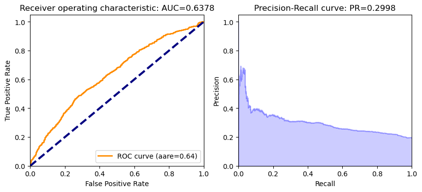

```python
ROC_AUC(aml_v1,test_hex,'loan_default')
```

```python
createGains(aml_v1)
```

```
glm prediction progress: |███████████████████████████████████████████████████████| (done) 100%
```

| decile | count | actual | non_actual | cum_count | cum_actual | cum_non_actual | percent_cum_actual | percent_cum_non_actual | if_random | lift | K_S | gain |
| --- | --- | --- | --- | --- | --- | --- | --- | --- | --- | --- | --- | --- |
| 0 | 320 | 112 | 208 | 320 | 112 | 208 | 0.18 | 0.08 | 61.8 | 1.81 | 10.0 | 35.00 |
| 1 | 320 | 86 | 234 | 640 | 198 | 442 | 0.32 | 0.17 | 123.6 | 1.60 | 15.0 | 30.94 |
| 2 | 320 | 89 | 231 | 960 | 287 | 673 | 0.46 | 0.26 | 185.4 | 1.55 | 20.0 | 29.90 |
| 3 | 320 | 54 | 266 | 1280 | 341 | 939 | 0.55 | 0.36 | 247.2 | 1.38 | 19.0 | 26.64 |
| 4 | 320 | 60 | 260 | 1600 | 401 | 1199 | 0.65 | 0.46 | 309.0 | 1.30 | 19.0 | 25.06 |
| 5 | 320 | 61 | 259 | 1920 | 462 | 1458 | 0.75 | 0.56 | 370.8 | 1.25 | 19.0 | 24.06 |
| 6 | 320 | 51 | 269 | 2240 | 513 | 1727 | 0.83 | 0.67 | 432.6 | 1.19 | 16.0 | 22.90 |
| 7 | 320 | 46 | 274 | 2560 | 559 | 2001 | 0.90 | 0.77 | 494.4 | 1.13 | 13.0 | 21.84 |
| 8 | 320 | 27 | 293 | 2880 | 586 | 2294 | 0.95 | 0.89 | 556.2 | 1.05 | 6.0 | 20.35 |
| 9 | 320 | 32 | 288 | 3200 | 618 | 2582 | 1.00 | 1.00 | 618.0 | 1.00 | 0.0 | 19.31 |

> Entire Dataset

```python
train_hex = h2o.H2OFrame(train)
test_hex = h2o.H2OFrame(test)
```

```
Parse progress: |████████████████████████████████████████████████████████████████| (done) 100%
Parse progress: |████████████████████████████████████████████████████████████████| (done) 100%
```

```python
# Run AutoML for 20 base models (limited to 1 hour max runtime by default)
aml_v2 = H2OAutoML(max_runtime_secs = 60, max_models=20, seed=1)
aml_v2.train(predictors,target,training_frame=train_hex)
```

[output not shown]

```
Model Details
=============
H2OGeneralizedLinearEstimator : Generalized Linear Modeling
Model Key: GLM_1_AutoML_2_20231202_13315
```

GLM Model: summary

|  | family | link | regularization | lambda_search | number_of_predictors_total | number_of_active_predictors | number_of_iterations | training_frame |
| --- | --- | --- | --- | --- | --- | --- | --- | --- |
|  | gaussian | identity | Ridge ( lambda = 0.00178 ) | nlambda = 30, lambda.max = 5.8577, lambda.min = 0.00178, lambda.1se = -1.0 | 139 | 129 | 18 | AutoML_2_20231202_13315_training_Key_Frame__upload_af1813980e0d1af4ccae66f57200458c.hex |

```
ModelMetricsRegressionGLM: glm
** Reported on train data. **

MSE: 0.14747151771752606
RMSE: 0.38402020482980587
MAE: 0.2958235130282851
RMSLE: 0.2695726662456619
Mean Residual Deviance: 0.14747151771752606
R^2: 0.05503162913126769
Null degrees of freedom: 33585
Residual degrees of freedom: 33456
Null deviance: 5241.422408145855
Residual deviance: 4952.97839406083
AIC: 31287.297374025835
```

```
ModelMetricsRegressionGLM: glm
** Reported on validation data. **

MSE: 0.14721862387119997
RMSE: 0.3836907920073141
MAE: 0.29487897855595635
RMSLE: 0.26954000643136944
Mean Residual Deviance: 0.14721862387119997
R^2: 0.04972433990982106
Null degrees of freedom: 4815
Residual degrees of freedom: 4686
Null deviance: 746.1209337928844
Residual deviance: 709.0048925636991
AIC: 4702.547079703849
```

Scoring History:

|  | timestamp | duration | iteration | lambda | predictors | deviance_train | deviance_test | alpha | iterations | training_rmse | training_deviance | training_mae | training_r2 | validation_rmse | validation_deviance | validation_mae | validation_r2 |
| --- | --- | --- | --- | --- | --- | --- | --- | --- | --- | --- | --- | --- | --- | --- | --- | --- | --- |
|  | 2023-12-02 01:33:35 | 0.000 sec | 1 | .59E1 | 130 | 0.1518458 | 0.1512496 | 0.0 | None |  |  |  |  |  |  |  |  |
|  | 2023-12-02 01:33:35 | 0.037 sec | 2 | .36E1 | 130 | 0.1509914 | 0.1505045 | 0.0 | None |  |  |  |  |  |  |  |  |
|  | 2023-12-02 01:33:35 | 0.042 sec | 3 | .23E1 | 130 | 0.1501911 | 0.1497931 | 0.0 | None |  |  |  |  |  |  |  |  |
|  | 2023-12-02 01:33:35 | 0.048 sec | 4 | .14E1 | 130 | 0.1494699 | 0.1491362 | 0.0 | None |  |  |  |  |  |  |  |  |
|  | 2023-12-02 01:33:35 | 0.052 sec | 5 | .87E0 | 130 | 0.1488593 | 0.1485641 | 0.0 | 5 | 0.3840202 | 0.1474715 | 0.2958235 | 0.0550316 | 0.3836908 | 0.1472186 | 0.2948790 | 0.0497243 |
|  | 2023-12-02 01:33:35 | 0.058 sec | 6 | .54E0 | 130 | 0.1483850 | 0.1481089 | 0.0 | None |  |  |  |  |  |  |  |  |
|  | 2023-12-02 01:33:35 | 0.063 sec | 7 | .34E0 | 130 | 0.1480550 | 0.1477844 | 0.0 | None |  |  |  |  |  |  |  |  |
|  | 2023-12-02 01:33:35 | 0.069 sec | 8 | .21E0 | 130 | 0.1478476 | 0.1475735 | 0.0 | None |  |  |  |  |  |  |  |  |
|  | 2023-12-02 01:33:35 | 0.077 sec | 9 | .13E0 | 130 | 0.1477249 | 0.1474469 | 0.0 | None |  |  |  |  |  |  |  |  |
|  | 2023-12-02 01:33:35 | 0.083 sec | 10 | .8E-1 | 130 | 0.1476539 | 0.1473732 | 0.0 | None |  |  |  |  |  |  |  |  |
| --- | --- | --- | --- | --- | --- | --- | --- | --- | --- | --- | --- | --- | --- | --- | --- | --- | --- |
|  | 2023-12-02 01:33:35 | 0.105 sec | 14 | .12E-1 | 130 | 0.1475463 | 0.1472657 | 0.0 | None |  |  |  |  |  |  |  |  |
|  | 2023-12-02 01:33:35 | 0.112 sec | 15 | .74E-2 | 130 | 0.1475296 | 0.1472488 | 0.0 | None |  |  |  |  |  |  |  |  |
|  | 2023-12-02 01:33:35 | 0.119 sec | 16 | .46E-2 | 130 | 0.1475120 | 0.1472337 | 0.0 | None |  |  |  |  |  |  |  |  |
|  | 2023-12-02 01:33:35 | 0.125 sec | 17 | .29E-2 | 130 | 0.1474928 | 0.1472229 | 0.0 | None |  |  |  |  |  |  |  |  |
|  | 2023-12-02 01:33:35 | 0.131 sec | 18 | .18E-2 | 130 | 0.1474715 | 0.1472186 | 0.0 | None |  |  |  |  |  |  |  |  |
|  | 2023-12-02 01:33:35 | 0.137 sec | 19 | .11E-2 | 130 | 0.1474477 | 0.1472228 | 0.0 | None |  |  |  |  |  |  |  |  |
|  | 2023-12-02 01:33:35 | 0.144 sec | 20 | .69E-3 | 130 | 0.1474213 | 0.1472360 | 0.0 | None |  |  |  |  |  |  |  |  |
|  | 2023-12-02 01:33:35 | 0.149 sec | 21 | .43E-3 | 130 | 0.1473921 | 0.1472576 | 0.0 | None |  |  |  |  |  |  |  |  |
|  | 2023-12-02 01:33:35 | 0.155 sec | 22 | .26E-3 | 130 | 0.1473597 | 0.1472860 | 0.0 | None |  |  |  |  |  |  |  |  |
|  | 2023-12-02 01:33:35 | 0.161 sec | 23 | .16E-3 | 130 | 0.1473238 | 0.1473189 | 0.0 | None |  |  |  |  |  |  |  |  |

```
[23 rows x 18 columns]
```

Variable Importances:

| variable | relative_importance | scaled_importance | percentage |
| --- | --- | --- | --- |
| MB007.GIONEE | 0.0634678 | 1.0 | 0.0498255 |
| MB007.LENOVO | 0.0613852 | 0.9671867 | 0.0481905 |
| AP003 | 0.0493129 | 0.7769751 | 0.0387131 |
| MB007.MEITU | 0.0483638 | 0.7620217 | 0.0379681 |
| MB007.DOOV | 0.0368758 | 0.5810166 | 0.0289494 |
| MB007.LEECO | 0.0334101 | 0.5264096 | 0.0262286 |
| TD013 | 0.0318523 | 0.5018662 | 0.0250057 |
| MB007.VIVO | 0.0283656 | 0.4469290 | 0.0222684 |
| MB007.NUBIA | 0.0269012 | 0.4238555 | 0.0211188 |
| MB005 | 0.0268384 | 0.4228662 | 0.0210695 |
| --- | --- | --- | --- |
| MB007.DAQ | 0.0 | 0.0 | 0.0 |
| MB007.GO | 0.0 | 0.0 | 0.0 |
| MB007.HMI | 0.0 | 0.0 | 0.0 |
| MB007.IPAD2 | 0.0 | 0.0 | 0.0 |
| MB007.KONKA | 0.0 | 0.0 | 0.0 |
| MB007.LINGWIN | 0.0 | 0.0 | 0.0 |
| MB007.MEDIATEK | 0.0 | 0.0 | 0.0 |
| MB007.TCT | 0.0 | 0.0 | 0.0 |
| MB007.YTONE_L985 | 0.0 | 0.0 | 0.0 |
| MB007.YU-FLY | 0.0 | 0.0 | 0.0 |

```
[139 rows x 4 columns]
```

```
[tips]
Use `model.explain()` to inspect the model.
--
Use `h2o.display.toggle_user_tips()` to switch on/off this section.
```

```python
aml_v2.leaderboard.head()
```

| model_id | rmse | mse | mae | rmsle | mean_residual_deviance |
| --- | --- | --- | --- | --- | --- |
| GLM_1_AutoML_2_20231202_13315 | 0.383691 | 0.147219 | 0.294879 | 0.26954 | 0.147219 |
| DeepLearning_1_AutoML_2_20231202_13315 | 0.383828 | 0.147324 | 0.288941 | 0.268419 | 0.147324 |
| GBM_5_AutoML_2_20231202_13315 | 0.383967 | 0.147431 | 0.294087 | 0.269665 | 0.147431 |
| GBM_3_AutoML_2_20231202_13315 | 0.3847 | 0.147994 | 0.294037 | 0.270486 | 0.147994 |
| GBM_2_AutoML_2_20231202_13315 | 0.384747 | 0.14803 | 0.294424 | 0.270222 | 0.14803 |
| GBM_1_AutoML_2_20231202_13315 | 0.385408 | 0.148539 | 0.292988 | 0.27099 | 0.148539 |
| XGBoost_3_AutoML_2_20231202_13315 | 0.385909 | 0.148926 | 0.293193 | 0.271662 | 0.148926 |
| GBM_4_AutoML_2_20231202_13315 | 0.388046 | 0.15058 | 0.294637 | 0.273226 | 0.15058 |
| DRF_1_AutoML_2_20231202_13315 | 0.389329 | 0.151577 | 0.300913 | 0.276083 | 0.151577 |
| XGBoost_2_AutoML_2_20231202_13315 | 0.405622 | 0.164529 | 0.300049 | 0.289077 | 0.164529 |

```
[10 rows x 6 columns]
```

> Predict using leaderboard

```python
pred = aml_v2.predict(test_hex)
pred.head()
```

```
glm prediction progress: |███████████████████████████████████████████████████████| (done) 100%
```

| predict |
| --- |
| 0.122151 |
| 0.145422 |
| 0.101502 |
| 0.225993 |
| 0.418348 |
| 0.161416 |
| 0.473326 |
| 0.247224 |
| 0.216372 |
| 0.103273 |

```
[10 rows x 1 column]
```

```python
perf = aml_v2.leader.model_performance(test_hex)
perf
```

```
ModelMetricsRegressionGLM: glm
** Reported on test data. **

MSE: 0.14885514157822674
RMSE: 0.3858174977605691
MAE: 0.2973543491126358
RMSLE: 0.2708889890594816
Mean Residual Deviance: 0.14885514157822674
R^2: 0.04987949761695065
Null degrees of freedom: 31999
Residual degrees of freedom: 31870
Null deviance: 5013.463792631178
Residual deviance: 4763.364530503256
AIC: 30121.053321686057
```

> ROC AUC Score in Test Data

```
glm prediction progress: |███████████████████████████████████████████████████████| (done) 100%

   * ROC curve: The ROC curve plots the true positive rate vs. the false rositive sate

   * The area under the curve (AUC): A value between 0.5 (random) and 1.0 (perfect), measuring the prediction accuracy

   * Recall (R) = The number of true positives / (the number of true positives + the number of false negatives)
```

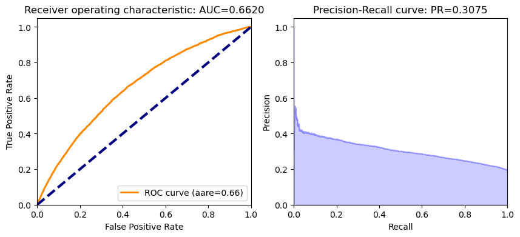

```python
ROC_AUC(aml_v2,test_hex,'loan_default')
```

```python
createGains(aml_v2)
```

```
glm prediction progress: |███████████████████████████████████████████████████████| (done) 100%
```

| decile | count | actual | non_actual | cum_count | cum_actual | cum_non_actual | percent_cum_actual | percent_cum_non_actual | if_random | lift | K_S | gain |
| --- | --- | --- | --- | --- | --- | --- | --- | --- | --- | --- | --- | --- |
| 0 | 3200 | 1181 | 2019 | 3200 | 1181 | 2019 | 0.19 | 0.08 | 622.4 | 1.90 | 11.0 | 36.91 |
| 1 | 3200 | 958 | 2242 | 6400 | 2139 | 4261 | 0.34 | 0.17 | 1244.8 | 1.72 | 17.0 | 33.42 |
| 2 | 3200 | 795 | 2405 | 9600 | 2934 | 6666 | 0.47 | 0.26 | 1867.2 | 1.57 | 21.0 | 30.56 |
| 3 | 3200 | 748 | 2452 | 12800 | 3682 | 9118 | 0.59 | 0.35 | 2489.6 | 1.48 | 24.0 | 28.77 |
| 4 | 3200 | 608 | 2592 | 16000 | 4290 | 11710 | 0.69 | 0.45 | 3112.0 | 1.38 | 24.0 | 26.81 |
| 5 | 3200 | 548 | 2652 | 19200 | 4838 | 14362 | 0.78 | 0.56 | 3734.4 | 1.30 | 22.0 | 25.20 |
| 6 | 3200 | 452 | 2748 | 22400 | 5290 | 17110 | 0.85 | 0.66 | 4356.8 | 1.21 | 19.0 | 23.62 |
| 7 | 3200 | 388 | 2812 | 25600 | 5678 | 19922 | 0.91 | 0.77 | 4979.2 | 1.14 | 14.0 | 22.18 |
| 8 | 3200 | 334 | 2866 | 28800 | 6012 | 22788 | 0.97 | 0.88 | 5601.6 | 1.07 | 9.0 | 20.88 |
| 9 | 3200 | 212 | 2988 | 32000 | 6224 | 25776 | 1.00 | 1.00 | 6224.0 | 1.00 | 0.0 | 19.45 |

> Using Under-Sampling Techniques

```python
y = df[target]
X = df.drop(target,axis=1)
```

```python
y1_cnt = df[target].sum()
y1_cnt
```

```
15488
```

```python
N = 2
y0_cnt = y1_cnt * N
y0_cnt
```

```
30976
```

```python
from imblearn.datasets import make_imbalance
X_rs, y_rs = make_imbalance(X, y,
                            sampling_strategy={1:y1_cnt , 0:  y0_cnt},
                            random_state=123)
X_rs = pd.DataFrame(X_rs)
y_rs = pd.DataFrame(y_rs)
```

```python
y_rs = df[df[target]==1]
X_rs = df[df[target]==0].sample(n=y0_cnt)
smpl = pd.concat([X_rs,y_rs])
train_smpl, test_smpl = train_test_split(
     smpl, test_size=0.40, random_state=42)
```

```python
train_hex = h2o.H2OFrame(train_smpl)
test_hex = h2o.H2OFrame(test_smpl)
```

```
Parse progress: |████████████████████████████████████████████████████████████████| (done) 100%
Parse progress: |████████████████████████████████████████████████████████████████| (done) 100%
```

```python
# Run AutoML for 20 base models (limited to 1 hour max runtime by default)
aml_v3 = H2OAutoML(max_runtime_secs = 60, max_models=20, seed=1)
aml_v3.train(predictors,target,training_frame=train_hex)
```

[output not shown]

```
Model Details
=============
H2OGeneralizedLinearEstimator : Generalized Linear Modeling
Model Key: GLM_1_AutoML_3_20231202_13424
```

GLM Model: summary

|  | family | link | regularization | lambda_search | number_of_predictors_total | number_of_active_predictors | number_of_iterations | training_frame |
| --- | --- | --- | --- | --- | --- | --- | --- | --- |
|  | gaussian | identity | Ridge ( lambda = 0.009809 ) | nlambda = 30, lambda.max = 7.7296, lambda.min = 0.009809, lambda.1se = -1.0 | 24309 | 17740 | 67 | AutoML_3_20231202_13424_training_Key_Frame__upload_9eb96de845c742b851d7e68a9c1d4fe2.hex |

```
ModelMetricsRegressionGLM: glm
** Reported on train data. **

MSE: 0.20529790541619025
RMSE: 0.45309811897224894
MAE: 0.4123608607652543
RMSLE: 0.31849097708510604
Mean Residual Deviance: 0.20529790541619025
R^2: 0.08017317578821281
Null degrees of freedom: 19534
Residual degrees of freedom: 1794
Null deviance: 4360.0539544406365
Residual deviance: 4010.4945823052767
AIC: 59992.29665935768
```

```
ModelMetricsRegressionGLM: glm
** Reported on validation data. **

MSE: 0.20574122636526274
RMSE: 0.45358706591487236
MAE: 0.41338918420472337
RMSLE: 0.319600724979624
Mean Residual Deviance: 0.20574122636526274
R^2: 0.07296809855764452
Null degrees of freedom: 2718
Residual degrees of freedom: -15022
Null deviance: 603.4815611914764
Residual deviance: 559.4103944871493
AIC: 38901.07873512904
```

Scoring History:

|  | timestamp | duration | iteration | lambda | predictors | deviance_train | deviance_test | alpha | iterations | training_rmse | training_deviance | training_mae | training_r2 | validation_rmse | validation_deviance | validation_mae | validation_r2 |
| --- | --- | --- | --- | --- | --- | --- | --- | --- | --- | --- | --- | --- | --- | --- | --- | --- | --- |
|  | 2023-12-02 01:34:36 | 0.000 sec | 3 | .77E1 | 17741 | 0.4331147 | 0.2151511 | 0.0 | None |  |  |  |  |  |  |  |  |
|  | 2023-12-02 01:34:36 | 0.030 sec | 6 | .56E1 | 17741 | 0.4308918 | 0.2140381 | 0.0 | None |  |  |  |  |  |  |  |  |
|  | 2023-12-02 01:34:36 | 0.067 sec | 9 | .41E1 | 17741 | 0.4286374 | 0.2129205 | 0.0 | None |  |  |  |  |  |  |  |  |
|  | 2023-12-02 01:34:36 | 5.534 sec | 11 | None | None |  |  |  | 11 | 0.4530981 | 0.2052979 | 0.4123609 | 0.0801732 | 0.4535871 | 0.2057412 | 0.4133892 | 0.0729681 |
|  | 2023-12-02 01:34:36 | 0.108 sec | 12 | .3E1 | 17741 | 0.4263988 | 0.2118265 | 0.0 | None |  |  |  |  |  |  |  |  |
|  | 2023-12-02 01:34:36 | 0.156 sec | 15 | .22E1 | 17741 | 0.4242165 | 0.2107782 | 0.0 | None |  |  |  |  |  |  |  |  |
|  | 2023-12-02 01:34:36 | 0.186 sec | 18 | .16E1 | 17741 | 0.4221347 | 0.2097973 | 0.0 | None |  |  |  |  |  |  |  |  |
|  | 2023-12-02 01:34:36 | 0.218 sec | 21 | .11E1 | 17741 | 0.4202046 | 0.2089065 | 0.0 | None |  |  |  |  |  |  |  |  |
|  | 2023-12-02 01:34:36 | 0.264 sec | 25 | .84E0 | 17741 | 0.4184720 | 0.2080972 | 0.0 | None |  |  |  |  |  |  |  |  |
|  | 2023-12-02 01:34:36 | 0.294 sec | 29 | .61E0 | 17741 | 0.4169890 | 0.2074323 | 0.0 | None |  |  |  |  |  |  |  |  |
| --- | --- | --- | --- | --- | --- | --- | --- | --- | --- | --- | --- | --- | --- | --- | --- | --- | --- |
|  | 2023-12-02 01:34:36 | 0.650 sec | 65 | .19E-1 | 17741 | 0.4106254 | 0.2057619 | 0.0 | None |  |  |  |  |  |  |  |  |
|  | 2023-12-02 01:34:36 | 0.661 sec | 66 | .13E-1 | 17741 | 0.4106056 | 0.2057561 | 0.0 | None |  |  |  |  |  |  |  |  |
|  | 2023-12-02 01:34:36 | 0.687 sec | 67 | .98E-2 | 17741 | 0.4105958 | 0.2057412 | 0.0 | None |  |  |  |  |  |  |  |  |
|  | 2023-12-02 01:34:36 | 0.697 sec | 68 | .71E-2 | 17741 | 0.4105729 | 0.2057662 | 0.0 | None |  |  |  |  |  |  |  |  |
|  | 2023-12-02 01:34:36 | 0.750 sec | 69 | .52E-2 | 17741 | 0.4105589 | 0.2057421 | 0.0 | None |  |  |  |  |  |  |  |  |
|  | 2023-12-02 01:34:36 | 0.761 sec | 70 | .38E-2 | 17741 | 0.4105333 | 0.2057765 | 0.0 | None |  |  |  |  |  |  |  |  |
|  | 2023-12-02 01:34:39 | 3.054 sec | 134 | .98E-2 | 41 | 0.4149071 | 0.2066925 | 0.6 | None |  |  |  |  |  |  |  |  |
|  | 2023-12-02 01:34:40 | 4.238 sec | 223 | .71E-2 | 42 | 0.4141011 | 0.2060936 | 0.6 | None |  |  |  |  |  |  |  |  |
|  | 2023-12-02 01:34:41 | 4.993 sec | 296 | .52E-2 | 26 | 0.4136584 | 0.2059415 | 0.6 | None |  |  |  |  |  |  |  |  |
|  | 2023-12-02 01:34:41 | 5.057 sec | 300 | .38E-2 | 43 | 0.4134739 | 0.2058105 | 0.6 | None |  |  |  |  |  |  |  |  |

```
[30 rows x 18 columns]
```

Variable Importances:

| variable | relative_importance | scaled_importance | percentage |
| --- | --- | --- | --- |
| AP003 | 0.0700369 | 1.0 | 0.0039135 |
| TD013 | 0.0432915 | 0.6181235 | 0.0024190 |
| AP006.android | 0.0425820 | 0.6079941 | 0.0023794 |
| MB005 | 0.0401801 | 0.5736981 | 0.0022451 |
| MB007.VIVO | 0.0318569 | 0.4548588 | 0.0017801 |
| TD009 | 0.0292405 | 0.4175017 | 0.0016339 |
| MB007.OPPO | 0.0278179 | 0.3971892 | 0.0015544 |
| MB007.HONOR | 0.0276255 | 0.3944423 | 0.0015436 |
| MB007.SAMSUNG | 0.0251212 | 0.3586852 | 0.0014037 |
| AP002 | 0.0239700 | 0.3422475 | 0.0013394 |
| --- | --- | --- | --- |
| AP005.2017/7/9 9:06 | 0.0 | 0.0 | 0.0 |
| AP005.2017/7/9 9:09 | 0.0 | 0.0 | 0.0 |
| MB007.BEN13 | 0.0 | 0.0 | 0.0 |
| MB007.DOOVL5PRO | 0.0 | 0.0 | 0.0 |
| MB007.HASEE | 0.0 | 0.0 | 0.0 |
| MB007.IPAD2 | 0.0 | 0.0 | 0.0 |
| MB007.IPAD6 | 0.0 | 0.0 | 0.0 |
| MB007.IPOD7 | 0.0 | 0.0 | 0.0 |
| MB007.MEDIATEK | 0.0 | 0.0 | 0.0 |
| MB007.ROAM_CAT | 0.0 | 0.0 | 0.0 |

```
[24309 rows x 4 columns]
```

```
[tips]
Use `model.explain()` to inspect the model.
--
Use `h2o.display.toggle_user_tips()` to switch on/off this section.
```

```python
aml_v3.leaderboard.head()
```

| model_id | rmse | mse | mae | rmsle | mean_residual_deviance |
| --- | --- | --- | --- | --- | --- |
| GLM_1_AutoML_3_20231202_13424 | 0.453587 | 0.205741 | 0.413389 | 0.319601 | 0.205741 |
| DeepLearning_1_AutoML_3_20231202_13424 | 0.454902 | 0.206935 | 0.392046 | 0.314087 | 0.206935 |
| GBM_1_AutoML_3_20231202_13424 | 0.455549 | 0.207525 | 0.410732 | 0.321163 | 0.207525 |
| GBM_5_AutoML_3_20231202_13424 | 0.455807 | 0.20776 | 0.413709 | 0.321199 | 0.20776 |
| GBM_3_AutoML_3_20231202_13424 | 0.456948 | 0.208802 | 0.412425 | 0.322104 | 0.208802 |
| GBM_2_AutoML_3_20231202_13424 | 0.458376 | 0.210108 | 0.41452 | 0.322749 | 0.210108 |
| GBM_4_AutoML_3_20231202_13424 | 0.459506 | 0.211146 | 0.41056 | 0.32387 | 0.211146 |
| XGBoost_3_AutoML_3_20231202_13424 | 0.460307 | 0.211882 | 0.412182 | 0.324358 | 0.211882 |
| DRF_1_AutoML_3_20231202_13424 | 0.462943 | 0.214316 | 0.419151 | 0.32762 | 0.214316 |
| XGBoost_2_AutoML_3_20231202_13424 | 0.493163 | 0.24321 | 0.420058 | 0.349383 | 0.24321 |

```
[10 rows x 6 columns]
```

> Predict using leaderboard

```python
pred = aml_v3.predict(test_hex)
pred.head()
```

```
glm prediction progress: |███████████████████████████████████████████████████████| (done) 100%
```

| predict |
| --- |
| 0.0889986 |
| 0.39446 |
| 0.330469 |
| 0.234883 |
| 0.374913 |
| 0.334163 |
| 0.264476 |
| 0.500526 |
| 0.345921 |
| 0.641782 |

```
[10 rows x 1 column]
```

```python
perf = aml_v3.leader.model_performance(test_hex)
perf
```

```
ModelMetricsRegressionGLM: glm
** Reported on test data. **

MSE: 0.2070491799355428
RMSE: 0.45502657058191975
MAE: 0.4146344377625757
RMSLE: 0.3206915881178134
Mean Residual Deviance: 0.2070491799355428
R^2: 0.06795250142574805
Null degrees of freedom: 18585
Residual degrees of freedom: 845
Null deviance: 4128.963307026663
Residual deviance: 3848.216058281999
AIC: 58959.57024877291
```

> ROC AUC Score in Train Data

```
glm prediction progress: |███████████████████████████████████████████████████████| (done) 100%

   * ROC curve: The ROC curve plots the true positive rate vs. the false rositive sate

   * The area under the curve (AUC): A value between 0.5 (random) and 1.0 (perfect), measuring the prediction accuracy

   * Recall (R) = The number of true positives / (the number of true positives + the number of false negatives)
```

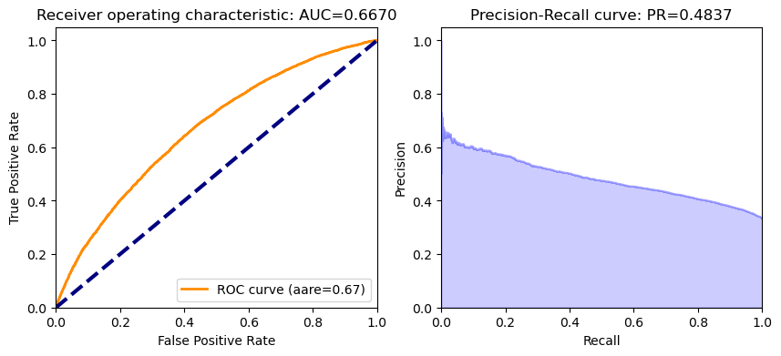

```python
ROC_AUC(aml_v3,train_hex,'loan_default')
```

> ROC AUC Score in Test Data

```
glm prediction progress: |███████████████████████████████████████████████████████| (done) 100%

   * ROC curve: The ROC curve plots the true positive rate vs. the false rositive sate

   * The area under the curve (AUC): A value between 0.5 (random) and 1.0 (perfect), measuring the prediction accuracy

   * Recall (R) = The number of true positives / (the number of true positives + the number of false negatives)
```

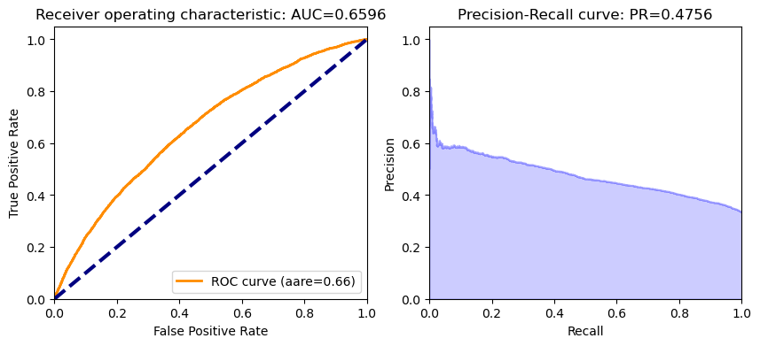

```python
ROC_AUC(aml_v3,test_hex,'loan_default')
```

```python
createGains(aml_v3)
```

```
glm prediction progress: |███████████████████████████████████████████████████████| (done) 100%
```

| decile | count | actual | non_actual | cum_count | cum_actual | cum_non_actual | percent_cum_actual | percent_cum_non_actual | if_random | lift | K_S | gain |
| --- | --- | --- | --- | --- | --- | --- | --- | --- | --- | --- | --- | --- |
| 0 | 1859 | 1041 | 818 | 1859 | 1041 | 818 | 0.17 | 0.07 | 619.1 | 1.68 | 10.0 | 56.00 |
| 1 | 1859 | 882 | 977 | 3718 | 1923 | 1795 | 0.31 | 0.14 | 1238.2 | 1.55 | 17.0 | 51.72 |
| 2 | 1858 | 779 | 1079 | 5576 | 2702 | 2874 | 0.44 | 0.23 | 1857.3 | 1.45 | 21.0 | 48.46 |
| 3 | 1859 | 681 | 1178 | 7435 | 3383 | 4052 | 0.55 | 0.33 | 2476.4 | 1.37 | 22.0 | 45.50 |
| 4 | 1858 | 662 | 1196 | 9293 | 4045 | 5248 | 0.65 | 0.42 | 3095.5 | 1.31 | 23.0 | 43.53 |
| 5 | 1859 | 592 | 1267 | 11152 | 4637 | 6515 | 0.75 | 0.53 | 3714.6 | 1.25 | 22.0 | 41.58 |
| 6 | 1859 | 490 | 1369 | 13011 | 5127 | 7884 | 0.83 | 0.64 | 4333.7 | 1.18 | 19.0 | 39.41 |
| 7 | 1858 | 430 | 1428 | 14869 | 5557 | 9312 | 0.90 | 0.75 | 4952.8 | 1.12 | 15.0 | 37.37 |
| 8 | 1859 | 387 | 1472 | 16728 | 5944 | 10784 | 0.96 | 0.87 | 5571.9 | 1.07 | 9.0 | 35.53 |
| 9 | 1858 | 247 | 1611 | 18586 | 6191 | 12395 | 1.00 | 1.00 | 6191.0 | 1.00 | 0.0 | 33.31 |

## Section 5: Model Summary & Conclusion

### Model `GLM`

> Model: glm_v1
> - Dataset used: 10% of entire data
> - Hyperparameters: Default setting
> - ROC AUC Score: `0.6339`
> - Precision-Recall: `0.2929`
> - In decile 0 subset: Lift: `1.89`, Gains: `36.56`

> Model: glm_v2
> - Dataset used: Entire data
> - Grid search range: `alpha`: [0.1, 0.3, 0.5], `lambda`: [1e-6, 1e-9, 1e-12]
> - Final Set of Hyperparameters: alpha = `0.1`, lambda = `1e-12`
> - ROC AUC Score: `0.6619`
> - Precision-Recall: `0.3064`
> - In decile 0 subset: Lift: `1.88`, Gains: `36.47`

### Model `AutoML`

- AutoML, an automated machine learning framework, revolutionizes the mortgage industry's risk assessment by efficiently handling model selection, hyperparameter tuning, and anomaly detection. In mortgage default prediction, AutoML conducts an exhaustive exploration across diverse algorithms such as Gradient Boosting Machines (GBM), Generalized Linear Models (GLM), Random Forests, and Neural Networks. By leveraging this array of models, it identifies the most accurate predictor of default probabilities, ensuring lenders have access to the most effective predictive tools for risk assessment. Simultaneously, AutoML's versatility extends to anomaly detection, meticulously examining discrepancies between predicted and expected outcomes across multiple models. This process allows for the identification of mortgage applications where predictions deviate significantly from historical norms, signaling potential anomalies or outliers requiring closer scrutiny. AutoML's holistic approach amalgamates various modeling techniques, empowering institutions to proactively manage risks by pinpointing atypical cases that might pose threats to mortgage portfolios.
- By automating model selection and evaluation, AutoML simplifies the machine learning pipeline, expediting the identification of the most suitable models for mortgage default prediction while enhancing anomaly detection capabilities.

> Model: `aml_v1`
> - Dataset used: 10% of entire data
> - Hyperparameters: default, `max_runtime_secs` = 60, `max_models` = 20
> - ROC AUC Score: `0.6378`
> - Precision-Recall: `0.2998`
> - In decile 0 subset: Lift: `1.81`, Gains: `35`

> Model: `aml_v2`
> - Dataset used: entire data
> - Hyperparameters: default, `max_runtime_secs` = 60, `max_models` = 20
> - ROC AUC Score: `0.6620`
> - Precision-Recall: `0.3075`
> - In decile 0 subset: Lift: `1.9`, Gains: `36.91`

> Model: `aml_v3`**(Best)**
> - Dataset used: Under-Sampling to create a more balanced training dataset. Set a ratio of one-third for the fraud cases in the new sample data.
> - Hyperparameters: default, `max_runtime_secs` = 60, `max_models` = 20
> - ROC AUC Score: `0.6596`
> - Precision-Recall: `0.4756`
> - In decile 0 subset: Lift: `1.68`, Gains: `56`